# AtliQ Hotels Data Analysis Project

### 3) Data Transformation

**Creating occupancy percentage column**

```python
df_agg_bookings["occ_pct"] = df_agg_bookings.successful_bookings/df_agg_bookings.capacity
df_agg_bookings["occ_pct"] = df_agg_bookings["occ_pct"].apply(lambda x: round(x*100,2))
df_agg_bookings.head()
```

|  | property_id | check_in_date | room_category | successful_bookings | capacity | occ_pct |
| --- | --- | --- | --- | --- | --- | --- |
| 0 | 16559 | 1-May-22 | RT1 | 25 | 30.0 | 83.33 |
| 1 | 19562 | 1-May-22 | RT1 | 28 | 30.0 | 93.33 |
| 2 | 19563 | 1-May-22 | RT1 | 23 | 30.0 | 76.67 |
| 4 | 16558 | 1-May-22 | RT1 | 18 | 19.0 | 94.74 |
| 5 | 17560 | 1-May-22 | RT1 | 28 | 40.0 | 70.00 |

### 4) Insights Generation

**1. What is the average occupancy rate in each of the room categories?**

```python
df_agg_bookings.groupby("room_category")["occ_pct"].mean()
```

```
room_category
RT1    57.889643
RT2    58.009756
RT3    58.028213
RT4    59.277925
Name: occ_pct, dtype: float64
```

```python
df_rooms
```

|  | room_id | room_class |
| --- | --- | --- |
| 0 | RT1 | Standard |
| 1 | RT2 | Elite |
| 2 | RT3 | Premium |
| 3 | RT4 | Presidential |

```python
#merging these two dataframes
pd.merge(df_rooms, df_agg_bookings.groupby("room_category")["occ_pct"].mean(), left_on = "room_id", right_on = "room_category")
```

|  | room_id | room_class | occ_pct |
| --- | --- | --- | --- |
| 0 | RT1 | Standard | 57.889643 |
| 1 | RT2 | Elite | 58.009756 |
| 2 | RT3 | Premium | 58.028213 |
| 3 | RT4 | Presidential | 59.277925 |

```python
#merging df_agg_bookings and df_rooms using the key room_id
df = pd.merge(df_agg_bookings,df_rooms, left_on = "room_category", right_on = "room_id")
df.head()
```

|  | property_id | check_in_date | room_category | successful_bookings | capacity | occ_pct | room_id | room_class |
| --- | --- | --- | --- | --- | --- | --- | --- | --- |
| 0 | 16559 | 1-May-22 | RT1 | 25 | 30.0 | 83.33 | RT1 | Standard |
| 1 | 19562 | 1-May-22 | RT1 | 28 | 30.0 | 93.33 | RT1 | Standard |
| 2 | 19563 | 1-May-22 | RT1 | 23 | 30.0 | 76.67 | RT1 | Standard |
| 3 | 16558 | 1-May-22 | RT1 | 18 | 19.0 | 94.74 | RT1 | Standard |
| 4 | 17560 | 1-May-22 | RT1 | 28 | 40.0 | 70.00 | RT1 | Standard |

```python
df.shape
```

```
(9194, 8)
```

```python
df.drop("room_id", axis = 1, inplace= True)
df.head()
```

|  | property_id | check_in_date | room_category | successful_bookings | capacity | occ_pct | room_class |
| --- | --- | --- | --- | --- | --- | --- | --- |
| 0 | 16559 | 1-May-22 | RT1 | 25 | 30.0 | 83.33 | Standard |
| 1 | 19562 | 1-May-22 | RT1 | 28 | 30.0 | 93.33 | Standard |
| 2 | 19563 | 1-May-22 | RT1 | 23 | 30.0 | 76.67 | Standard |
| 3 | 16558 | 1-May-22 | RT1 | 18 | 19.0 | 94.74 | Standard |
| 4 | 17560 | 1-May-22 | RT1 | 28 | 40.0 | 70.00 | Standard |

```python
df.groupby("room_class")["occ_pct"].mean()
```

```
room_class
Elite           58.009756
Premium         58.028213
Presidential    59.277925
Standard        57.889643
Name: occ_pct, dtype: float64
```

**2. What is the average occupancy rate per city?**

```python
df_hotels.head()
```

|  | property_id | property_name | category | city |
| --- | --- | --- | --- | --- |
| 0 | 16558 | Atliq Grands | Luxury | Delhi |
| 1 | 16559 | Atliq Exotica | Luxury | Mumbai |
| 2 | 16560 | Atliq City | Business | Delhi |
| 3 | 16561 | Atliq Blu | Luxury | Delhi |
| 4 | 16562 | Atliq Bay | Luxury | Delhi |

```python
df = pd.merge(df,df_hotels,on="property_id")
df.head()
```

|  | property_id | check_in_date | room_category | successful_bookings | capacity | occ_pct | room_class | property_name | category | city |
| --- | --- | --- | --- | --- | --- | --- | --- | --- | --- | --- |
| 0 | 16559 | 1-May-22 | RT1 | 25 | 30.0 | 83.33 | Standard | Atliq Exotica | Luxury | Mumbai |
| 1 | 19562 | 1-May-22 | RT1 | 28 | 30.0 | 93.33 | Standard | Atliq Bay | Luxury | Bangalore |
| 2 | 19563 | 1-May-22 | RT1 | 23 | 30.0 | 76.67 | Standard | Atliq Palace | Business | Bangalore |
| 3 | 16558 | 1-May-22 | RT1 | 18 | 19.0 | 94.74 | Standard | Atliq Grands | Luxury | Delhi |
| 4 | 17560 | 1-May-22 | RT1 | 28 | 40.0 | 70.00 | Standard | Atliq City | Business | Mumbai |

```python
df.shape
```

```
(9194, 10)
```

```
city
Bangalore    56.332376
Delhi        61.507341
Hyderabad    58.120652
Mumbai       57.909181
Name: occ_pct, dtype: float64
```

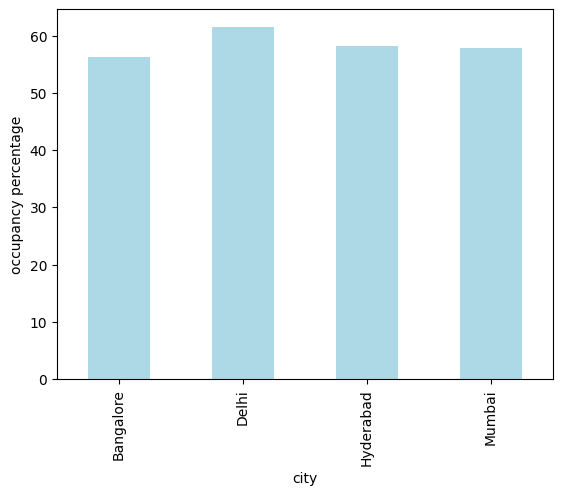

```python
print(df.groupby("city")["occ_pct"].mean())
df.groupby("city")["occ_pct"].mean().plot(kind="bar", ylabel = "occupancy percentage",color="lightblue")
```

**3. When was the occupancy better? Weekday or Weekend?**

```python
df_date.head()
```

|  | date | mmm yy | week no | day_type |
| --- | --- | --- | --- | --- |
| 0 | 01-May-22 | May 22 | W 19 | weekend |
| 1 | 02-May-22 | May 22 | W 19 | weekeday |
| 2 | 03-May-22 | May 22 | W 19 | weekeday |
| 3 | 04-May-22 | May 22 | W 19 | weekeday |
| 4 | 05-May-22 | May 22 | W 19 | weekeday |

```python
df.head()
```

|  | property_id | check_in_date | room_category | successful_bookings | capacity | occ_pct | room_class | property_name | category | city |
| --- | --- | --- | --- | --- | --- | --- | --- | --- | --- | --- |
| 0 | 16559 | 1-May-22 | RT1 | 25 | 30.0 | 83.33 | Standard | Atliq Exotica | Luxury | Mumbai |
| 1 | 19562 | 1-May-22 | RT1 | 28 | 30.0 | 93.33 | Standard | Atliq Bay | Luxury | Bangalore |
| 2 | 19563 | 1-May-22 | RT1 | 23 | 30.0 | 76.67 | Standard | Atliq Palace | Business | Bangalore |
| 3 | 16558 | 1-May-22 | RT1 | 18 | 19.0 | 94.74 | Standard | Atliq Grands | Luxury | Delhi |
| 4 | 17560 | 1-May-22 | RT1 | 28 | 40.0 | 70.00 | Standard | Atliq City | Business | Mumbai |

**While merging df and df_date most of the rows might be dropped as date types in both the dataframes are inconsistent. So, we will first change them in the same date type.**

```python
# Convert 'date' column in df_date to datetime
df_date["date"] = pd.to_datetime(df_date["date"], format="%d-%b-%y")

# Reformat the 'date' column in df_date to 'dd-MMM-yy' format
df_date['date'] = df_date['date'].dt.strftime('%d-%b-%y')

df_date.head()
```

|  | date | mmm yy | week no | day_type |
| --- | --- | --- | --- | --- |
| 0 | 01-May-22 | May 22 | W 19 | weekend |
| 1 | 02-May-22 | May 22 | W 19 | weekeday |
| 2 | 03-May-22 | May 22 | W 19 | weekeday |
| 3 | 04-May-22 | May 22 | W 19 | weekeday |
| 4 | 05-May-22 | May 22 | W 19 | weekeday |

```python
# Convert 'check_in_date' to datetime
df["check_in_date"] = pd.to_datetime(df["check_in_date"], format="%d-%b-%y")

# Reformat the 'check_in_date' to 'dd-MMM-yy' format
df['check_in_date'] = df['check_in_date'].dt.strftime('%d-%b-%y')

print(df.shape)
df.head()
```

```
(9194, 10)
```

|  | property_id | check_in_date | room_category | successful_bookings | capacity | occ_pct | room_class | property_name | category | city |
| --- | --- | --- | --- | --- | --- | --- | --- | --- | --- | --- |
| 0 | 16559 | 01-May-22 | RT1 | 25 | 30.0 | 83.33 | Standard | Atliq Exotica | Luxury | Mumbai |
| 1 | 19562 | 01-May-22 | RT1 | 28 | 30.0 | 93.33 | Standard | Atliq Bay | Luxury | Bangalore |
| 2 | 19563 | 01-May-22 | RT1 | 23 | 30.0 | 76.67 | Standard | Atliq Palace | Business | Bangalore |
| 3 | 16558 | 01-May-22 | RT1 | 18 | 19.0 | 94.74 | Standard | Atliq Grands | Luxury | Delhi |
| 4 | 17560 | 01-May-22 | RT1 | 28 | 40.0 | 70.00 | Standard | Atliq City | Business | Mumbai |

```python
df = pd.merge(df, df_date, left_on = "check_in_date", right_on = "date", how = "left")
print(df.shape)
df.head()
```

```
(9194, 14)
```

|  | property_id | check_in_date | room_category | successful_bookings | capacity | occ_pct | room_class | property_name | category | city | date | mmm yy | week no | day_type |
| --- | --- | --- | --- | --- | --- | --- | --- | --- | --- | --- | --- | --- | --- | --- |
| 0 | 16559 | 01-May-22 | RT1 | 25 | 30.0 | 83.33 | Standard | Atliq Exotica | Luxury | Mumbai | 01-May-22 | May 22 | W 19 | weekend |
| 1 | 19562 | 01-May-22 | RT1 | 28 | 30.0 | 93.33 | Standard | Atliq Bay | Luxury | Bangalore | 01-May-22 | May 22 | W 19 | weekend |
| 2 | 19563 | 01-May-22 | RT1 | 23 | 30.0 | 76.67 | Standard | Atliq Palace | Business | Bangalore | 01-May-22 | May 22 | W 19 | weekend |
| 3 | 16558 | 01-May-22 | RT1 | 18 | 19.0 | 94.74 | Standard | Atliq Grands | Luxury | Delhi | 01-May-22 | May 22 | W 19 | weekend |
| 4 | 17560 | 01-May-22 | RT1 | 28 | 40.0 | 70.00 | Standard | Atliq City | Business | Mumbai | 01-May-22 | May 22 | W 19 | weekend |

```python
df.drop("date", axis = 1, inplace = True)
df.head(3)
```

|  | property_id | check_in_date | room_category | successful_bookings | capacity | occ_pct | room_class | property_name | category | city | mmm yy | week no | day_type |
| --- | --- | --- | --- | --- | --- | --- | --- | --- | --- | --- | --- | --- | --- |
| 0 | 16559 | 01-May-22 | RT1 | 25 | 30.0 | 83.33 | Standard | Atliq Exotica | Luxury | Mumbai | May 22 | W 19 | weekend |
| 1 | 19562 | 01-May-22 | RT1 | 28 | 30.0 | 93.33 | Standard | Atliq Bay | Luxury | Bangalore | May 22 | W 19 | weekend |
| 2 | 19563 | 01-May-22 | RT1 | 23 | 30.0 | 76.67 | Standard | Atliq Palace | Business | Bangalore | May 22 | W 19 | weekend |

```python
df.groupby("day_type")["occ_pct"].mean()
```

```
day_type
weekeday    51.807975
weekend     73.960616
Name: occ_pct, dtype: float64
```

**4: In the month of June, what is the mean occupancy for different cities?**

```python
df["mmm yy"].unique()
```

```
array(['May 22', 'Jun 22', 'Jul 22'], dtype=object)
```

```python
df.check_in_date.unique()
```

```
array(['01-May-22', '02-May-22', '03-May-22', '04-May-22', '05-May-22',
       '06-May-22', '07-May-22', '08-May-22', '09-May-22', '10-May-22',
       '11-May-22', '12-May-22', '13-May-22', '14-May-22', '15-May-22',
       '16-May-22', '17-May-22', '18-May-22', '19-May-22', '20-May-22',
       '21-May-22', '22-May-22', '23-May-22', '24-May-22', '25-May-22',
       '26-May-22', '27-May-22', '28-May-22', '29-May-22', '30-May-22',
       '31-May-22', '01-Jun-22', '02-Jun-22', '03-Jun-22', '04-Jun-22',
       '05-Jun-22', '06-Jun-22', '07-Jun-22', '08-Jun-22', '09-Jun-22',
       '10-Jun-22', '11-Jun-22', '12-Jun-22', '13-Jun-22', '14-Jun-22',
       '15-Jun-22', '16-Jun-22', '17-Jun-22', '18-Jun-22', '19-Jun-22',
       '20-Jun-22', '21-Jun-22', '22-Jun-22', '23-Jun-22', '24-Jun-22',
       '25-Jun-22', '26-Jun-22', '27-Jun-22', '28-Jun-22', '29-Jun-22',
       '30-Jun-22', '01-Jul-22', '02-Jul-22', '03-Jul-22', '04-Jul-22',
       '05-Jul-22', '06-Jul-22', '07-Jul-22', '08-Jul-22', '09-Jul-22',
       '10-Jul-22', '11-Jul-22', '12-Jul-22', '13-Jul-22', '14-Jul-22',
       '15-Jul-22', '16-Jul-22', '17-Jul-22', '18-Jul-22', '19-Jul-22',
       '20-Jul-22', '21-Jul-22', '22-Jul-22', '23-Jul-22', '24-Jul-22',
       '25-Jul-22', '26-Jul-22', '27-Jul-22', '28-Jul-22', '29-Jul-22',
       '30-Jul-22', '31-Jul-22'], dtype=object)
```

```python
df[df["mmm yy"]=="Jun 22"].groupby("city")["occ_pct"].mean()
```

```
city
Bangalore    55.849527
Delhi        61.456367
Hyderabad    57.688917
Mumbai       57.789542
Name: occ_pct, dtype: float64
```

**5: We got new data for the month of august. Append that to existing data**

```python
df_new_aug
```

|  | property_id | property_name | category | city | room_category | room_class | check_in_date | mmm yy | week no | day_type | successful_bookings | capacity | occ% |
| --- | --- | --- | --- | --- | --- | --- | --- | --- | --- | --- | --- | --- | --- |
| 0 | 16559 | Atliq Exotica | Luxury | Mumbai | RT1 | Standard | 01-Aug-22 | Aug-22 | W 32 | weekeday | 30 | 30 | 100.00 |
| 1 | 19562 | Atliq Bay | Luxury | Bangalore | RT1 | Standard | 01-Aug-22 | Aug-22 | W 32 | weekeday | 21 | 30 | 70.00 |
| 2 | 19563 | Atliq Palace | Business | Bangalore | RT1 | Standard | 01-Aug-22 | Aug-22 | W 32 | weekeday | 23 | 30 | 76.67 |
| 3 | 19558 | Atliq Grands | Luxury | Bangalore | RT1 | Standard | 01-Aug-22 | Aug-22 | W 32 | weekeday | 30 | 40 | 75.00 |
| 4 | 19560 | Atliq City | Business | Bangalore | RT1 | Standard | 01-Aug-22 | Aug-22 | W 32 | weekeday | 20 | 26 | 76.92 |
| 5 | 17561 | Atliq Blu | Luxury | Mumbai | RT1 | Standard | 01-Aug-22 | Aug-22 | W 32 | weekeday | 18 | 26 | 69.23 |
| 6 | 17564 | Atliq Seasons | Business | Mumbai | RT1 | Standard | 01-Aug-22 | Aug-22 | W 32 | weekeday | 10 | 16 | 62.50 |

```python
df.head(3)
```

|  | property_id | check_in_date | room_category | successful_bookings | capacity | occ_pct | room_class | property_name | category | city | mmm yy | week no | day_type |
| --- | --- | --- | --- | --- | --- | --- | --- | --- | --- | --- | --- | --- | --- |
| 0 | 16559 | 01-May-22 | RT1 | 25 | 30.0 | 83.33 | Standard | Atliq Exotica | Luxury | Mumbai | May 22 | W 19 | weekend |
| 1 | 19562 | 01-May-22 | RT1 | 28 | 30.0 | 93.33 | Standard | Atliq Bay | Luxury | Bangalore | May 22 | W 19 | weekend |
| 2 | 19563 | 01-May-22 | RT1 | 23 | 30.0 | 76.67 | Standard | Atliq Palace | Business | Bangalore | May 22 | W 19 | weekend |

```python
print(df_new_aug.shape,df.shape)
```

```
(7, 13) (9194, 13)
```

```python
df_new_aug.rename(columns={"occ%": "occ_pct"}, inplace=True)
```

```python
df_latest = pd.concat([df,df_new_aug],ignore_index = True)
df_latest.head(3)
```

|  | property_id | check_in_date | room_category | successful_bookings | capacity | occ_pct | room_class | property_name | category | city | mmm yy | week no | day_type |
| --- | --- | --- | --- | --- | --- | --- | --- | --- | --- | --- | --- | --- | --- |
| 0 | 16559 | 01-May-22 | RT1 | 25 | 30.0 | 83.33 | Standard | Atliq Exotica | Luxury | Mumbai | May 22 | W 19 | weekend |
| 1 | 19562 | 01-May-22 | RT1 | 28 | 30.0 | 93.33 | Standard | Atliq Bay | Luxury | Bangalore | May 22 | W 19 | weekend |
| 2 | 19563 | 01-May-22 | RT1 | 23 | 30.0 | 76.67 | Standard | Atliq Palace | Business | Bangalore | May 22 | W 19 | weekend |

```python
df_latest.shape
```

```
(9201, 13)
```

**6. Finding revenue realized per city**

```python
print(df_bookings.shape)
df_bookings.head(3)
```

```
(134573, 12)
```

|  | booking_id | property_id | booking_date | check_in_date | checkout_date | no_guests | room_category | booking_platform | ratings_given | booking_status | revenue_generated | revenue_realized |
| --- | --- | --- | --- | --- | --- | --- | --- | --- | --- | --- | --- | --- |
| 1 | May012216558RT12 | 16558 | 30-04-22 | 1/5/2022 | 2/5/2022 | 2.0 | RT1 | others | NaN | Cancelled | 9100 | 3640 |
| 4 | May012216558RT15 | 16558 | 27-04-22 | 1/5/2022 | 2/5/2022 | 4.0 | RT1 | direct online | 5.0 | Checked Out | 10920 | 10920 |
| 5 | May012216558RT16 | 16558 | 1/5/2022 | 1/5/2022 | 3/5/2022 | 2.0 | RT1 | others | 4.0 | Checked Out | 9100 | 9100 |

```python
df_hotels.head(3)
```

|  | property_id | property_name | category | city |
| --- | --- | --- | --- | --- |
| 0 | 16558 | Atliq Grands | Luxury | Delhi |
| 1 | 16559 | Atliq Exotica | Luxury | Mumbai |
| 2 | 16560 | Atliq City | Business | Delhi |

```python
df_bookings_merged = pd.merge(df_bookings,df_hotels, on = "property_id")
print(df_bookings_merged.shape)
df_bookings_merged.head(3)
```

```
(134573, 15)
```

|  | booking_id | property_id | booking_date | check_in_date | checkout_date | no_guests | room_category | booking_platform | ratings_given | booking_status | revenue_generated | revenue_realized | property_name | category | city |
| --- | --- | --- | --- | --- | --- | --- | --- | --- | --- | --- | --- | --- | --- | --- | --- |
| 0 | May012216558RT12 | 16558 | 30-04-22 | 1/5/2022 | 2/5/2022 | 2.0 | RT1 | others | NaN | Cancelled | 9100 | 3640 | Atliq Grands | Luxury | Delhi |
| 1 | May012216558RT15 | 16558 | 27-04-22 | 1/5/2022 | 2/5/2022 | 4.0 | RT1 | direct online | 5.0 | Checked Out | 10920 | 10920 | Atliq Grands | Luxury | Delhi |
| 2 | May012216558RT16 | 16558 | 1/5/2022 | 1/5/2022 | 3/5/2022 | 2.0 | RT1 | others | 4.0 | Checked Out | 9100 | 9100 | Atliq Grands | Luxury | Delhi |

```python
df_bookings_merged.groupby("city")["revenue_realized"].sum()
```

```
city
Bangalore    420383550
Delhi        294404488
Hyderabad    325179310
Mumbai       668569251
Name: revenue_realized, dtype: int64
```

**7. Print month by month revenue**

```python
df_date.head(3)
```

|  | date | mmm yy | week no | day_type |
| --- | --- | --- | --- | --- |
| 0 | 01-May-22 | May 22 | W 19 | weekend |
| 1 | 02-May-22 | May 22 | W 19 | weekeday |
| 2 | 03-May-22 | May 22 | W 19 | weekeday |

```python
df_bookings_merged.head(3)
```

|  | booking_id | property_id | booking_date | check_in_date | checkout_date | no_guests | room_category | booking_platform | ratings_given | booking_status | revenue_generated | revenue_realized | property_name | category | city |
| --- | --- | --- | --- | --- | --- | --- | --- | --- | --- | --- | --- | --- | --- | --- | --- |
| 0 | May012216558RT12 | 16558 | 30-04-22 | 1/5/2022 | 2/5/2022 | 2.0 | RT1 | others | NaN | Cancelled | 9100 | 3640 | Atliq Grands | Luxury | Delhi |
| 1 | May012216558RT15 | 16558 | 27-04-22 | 1/5/2022 | 2/5/2022 | 4.0 | RT1 | direct online | 5.0 | Checked Out | 10920 | 10920 | Atliq Grands | Luxury | Delhi |
| 2 | May012216558RT16 | 16558 | 1/5/2022 | 1/5/2022 | 3/5/2022 | 2.0 | RT1 | others | 4.0 | Checked Out | 9100 | 9100 | Atliq Grands | Luxury | Delhi |

```python
# Convert 'check_in_date' to datetime
df_bookings_merged["check_in_date"] = pd.to_datetime(df_bookings_merged["check_in_date"], format="mixed", dayfirst = True)

# Reformat the 'check_in_date' to 'dd-MMM-yy' format
df_bookings_merged['check_in_date'] = df_bookings_merged['check_in_date'].dt.strftime('%d-%b-%y')
```

```python
print(df_bookings_merged.shape)
df_bookings_merged.head(3)
```

```
(134573, 15)
```

|  | booking_id | property_id | booking_date | check_in_date | checkout_date | no_guests | room_category | booking_platform | ratings_given | booking_status | revenue_generated | revenue_realized | property_name | category | city |
| --- | --- | --- | --- | --- | --- | --- | --- | --- | --- | --- | --- | --- | --- | --- | --- |
| 0 | May012216558RT12 | 16558 | 30-04-22 | 01-May-22 | 2/5/2022 | 2.0 | RT1 | others | NaN | Cancelled | 9100 | 3640 | Atliq Grands | Luxury | Delhi |
| 1 | May012216558RT15 | 16558 | 27-04-22 | 01-May-22 | 2/5/2022 | 4.0 | RT1 | direct online | 5.0 | Checked Out | 10920 | 10920 | Atliq Grands | Luxury | Delhi |
| 2 | May012216558RT16 | 16558 | 1/5/2022 | 01-May-22 | 3/5/2022 | 2.0 | RT1 | others | 4.0 | Checked Out | 9100 | 9100 | Atliq Grands | Luxury | Delhi |

```python
df_bookings_merged = pd.merge(df_bookings_merged,df_date,left_on = "check_in_date", right_on = "date", how = "left")
```

```python
df_bookings_merged.drop("date", axis = 1, inplace = True)
```

```python
df_bookings_merged.head(3)
```

|  | booking_id | property_id | booking_date | check_in_date | checkout_date | no_guests | room_category | booking_platform | ratings_given | booking_status | revenue_generated | revenue_realized | property_name | category | city | mmm yy | week no | day_type |
| --- | --- | --- | --- | --- | --- | --- | --- | --- | --- | --- | --- | --- | --- | --- | --- | --- | --- | --- |
| 0 | May012216558RT12 | 16558 | 30-04-22 | 01-May-22 | 2/5/2022 | 2.0 | RT1 | others | NaN | Cancelled | 9100 | 3640 | Atliq Grands | Luxury | Delhi | May 22 | W 19 | weekend |
| 1 | May012216558RT15 | 16558 | 27-04-22 | 01-May-22 | 2/5/2022 | 4.0 | RT1 | direct online | 5.0 | Checked Out | 10920 | 10920 | Atliq Grands | Luxury | Delhi | May 22 | W 19 | weekend |
| 2 | May012216558RT16 | 16558 | 1/5/2022 | 01-May-22 | 3/5/2022 | 2.0 | RT1 | others | 4.0 | Checked Out | 9100 | 9100 | Atliq Grands | Luxury | Delhi | May 22 | W 19 | weekend |

```python
df_bookings_merged.groupby("mmm yy")["revenue_realized"].sum()
```

```
mmm yy
Jul 22    572843348
Jun 22    553925855
May 22    581767396
Name: revenue_realized, dtype: int64
```

```python
df_bookings_merged.revenue_realized.sum()
```

```
np.int64(1708536599)
```

**8. Finding average ratings and revenue realized per hotel name.**

```python
print(df_bookings_merged.groupby("property_name")["ratings_given"].mean())
print()
print(df_bookings_merged.groupby("property_name")["revenue_realized"].sum())
```

```
property_name
Atliq Bay        3.708943
Atliq Blu        3.959650
Atliq City       3.694799
Atliq Exotica    3.619241
Atliq Grands     3.099779
Atliq Palace     3.749545
Atliq Seasons    2.295033
Name: ratings_given, dtype: float64

property_name
Atliq Bay        259996918
Atliq Blu        260851922
Atliq City       285798439
Atliq Exotica    320258588
Atliq Grands     211462134
Atliq Palace     304081863
Atliq Seasons     66086735
Name: revenue_realized, dtype: int64
```

```python
df.head(3)
```

|  | property_id | check_in_date | room_category | successful_bookings | capacity | occ_pct | room_class | property_name | category | city | mmm yy | week no | day_type |
| --- | --- | --- | --- | --- | --- | --- | --- | --- | --- | --- | --- | --- | --- |
| 0 | 16559 | 01-May-22 | RT1 | 25 | 30.0 | 83.33 | Standard | Atliq Exotica | Luxury | Mumbai | May 22 | W 19 | weekend |
| 1 | 19562 | 01-May-22 | RT1 | 28 | 30.0 | 93.33 | Standard | Atliq Bay | Luxury | Bangalore | May 22 | W 19 | weekend |
| 2 | 19563 | 01-May-22 | RT1 | 23 | 30.0 | 76.67 | Standard | Atliq Palace | Business | Bangalore | May 22 | W 19 | weekend |

```python
print(df_bookings_merged.shape)
df_bookings_merged.head(3)
```

```
(134573, 18)
```

|  | booking_id | property_id | booking_date | check_in_date | checkout_date | no_guests | room_category | booking_platform | ratings_given | booking_status | revenue_generated | revenue_realized | property_name | category | city | mmm yy | week no | day_type |
| --- | --- | --- | --- | --- | --- | --- | --- | --- | --- | --- | --- | --- | --- | --- | --- | --- | --- | --- |
| 0 | May012216558RT12 | 16558 | 30-04-22 | 01-May-22 | 2/5/2022 | 2.0 | RT1 | others | NaN | Cancelled | 9100 | 3640 | Atliq Grands | Luxury | Delhi | May 22 | W 19 | weekend |
| 1 | May012216558RT15 | 16558 | 27-04-22 | 01-May-22 | 2/5/2022 | 4.0 | RT1 | direct online | 5.0 | Checked Out | 10920 | 10920 | Atliq Grands | Luxury | Delhi | May 22 | W 19 | weekend |
| 2 | May012216558RT16 | 16558 | 1/5/2022 | 01-May-22 | 3/5/2022 | 2.0 | RT1 | others | 4.0 | Checked Out | 9100 | 9100 | Atliq Grands | Luxury | Delhi | May 22 | W 19 | weekend |

```python
df_bookings_merged = pd.merge(df_bookings_merged,df_rooms, left_on = "room_category", right_on = "room_id")
```

```python
print(df_bookings_merged.shape)
df_bookings_merged.head(3)
```

```
(134573, 20)
```

|  | booking_id | property_id | booking_date | check_in_date | checkout_date | no_guests | room_category | booking_platform | ratings_given | booking_status | revenue_generated | revenue_realized | property_name | category | city | mmm yy | week no | day_type | room_id | room_class |
| --- | --- | --- | --- | --- | --- | --- | --- | --- | --- | --- | --- | --- | --- | --- | --- | --- | --- | --- | --- | --- |
| 0 | May012216558RT12 | 16558 | 30-04-22 | 01-May-22 | 2/5/2022 | 2.0 | RT1 | others | NaN | Cancelled | 9100 | 3640 | Atliq Grands | Luxury | Delhi | May 22 | W 19 | weekend | RT1 | Standard |
| 1 | May012216558RT15 | 16558 | 27-04-22 | 01-May-22 | 2/5/2022 | 4.0 | RT1 | direct online | 5.0 | Checked Out | 10920 | 10920 | Atliq Grands | Luxury | Delhi | May 22 | W 19 | weekend | RT1 | Standard |
| 2 | May012216558RT16 | 16558 | 1/5/2022 | 01-May-22 | 3/5/2022 | 2.0 | RT1 | others | 4.0 | Checked Out | 9100 | 9100 | Atliq Grands | Luxury | Delhi | May 22 | W 19 | weekend | RT1 | Standard |

```python
df_bookings_merged.drop("room_id",axis=1,inplace=True)
print(df_bookings_merged.shape)
df_bookings_merged.head(3)
```

```
(134573, 19)
```

|  | booking_id | property_id | booking_date | check_in_date | checkout_date | no_guests | room_category | booking_platform | ratings_given | booking_status | revenue_generated | revenue_realized | property_name | category | city | mmm yy | week no | day_type | room_class |
| --- | --- | --- | --- | --- | --- | --- | --- | --- | --- | --- | --- | --- | --- | --- | --- | --- | --- | --- | --- |
| 0 | May012216558RT12 | 16558 | 30-04-22 | 01-May-22 | 2/5/2022 | 2.0 | RT1 | others | NaN | Cancelled | 9100 | 3640 | Atliq Grands | Luxury | Delhi | May 22 | W 19 | weekend | Standard |
| 1 | May012216558RT15 | 16558 | 27-04-22 | 01-May-22 | 2/5/2022 | 4.0 | RT1 | direct online | 5.0 | Checked Out | 10920 | 10920 | Atliq Grands | Luxury | Delhi | May 22 | W 19 | weekend | Standard |
| 2 | May012216558RT16 | 16558 | 1/5/2022 | 01-May-22 | 3/5/2022 | 2.0 | RT1 | others | 4.0 | Checked Out | 9100 | 9100 | Atliq Grands | Luxury | Delhi | May 22 | W 19 | weekend | Standard |

### 5) Data Visualization

**1. Pie chart of revenue realized per booking platform**

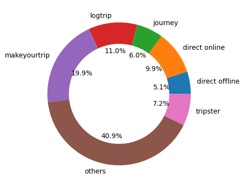

```python
df_bookings_merged.groupby("booking_platform")["revenue_realized"].sum().plot(kind="pie", ylabel = "",autopct='%1.1f%%',wedgeprops=dict(width=0.3))
```

```python
a = (df_bookings_merged.groupby('room_class')['revenue_realized'].sum())/1000000
print(a.iloc[1])
print(a)
```

```
462.079944
room_class
Elite           560.216304
Premium         462.079944
Presidential    376.693126
Standard        309.547225
Name: revenue_realized, dtype: float64
```

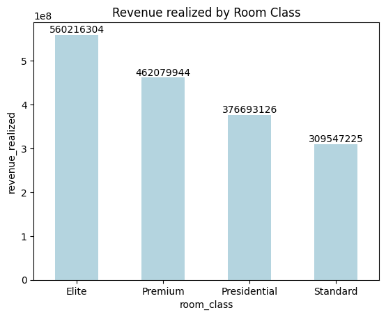

```python
import seaborn as sns

rcbyrr = df_bookings_merged.groupby('room_class',as_index=False)['revenue_realized'].sum()
# rcbyrr["revenue_realized"] = rcbyrr["revenue_realized"]/1000000
ax = sns.barplot(x='room_class', y="revenue_realized", data=rcbyrr, width = 0.5, color = "lightblue")
plt.title('Revenue realized by Room Class')
for bar in ax.containers:
    ax.bar_label(bar, fmt='%.0f')
plt.show()
```

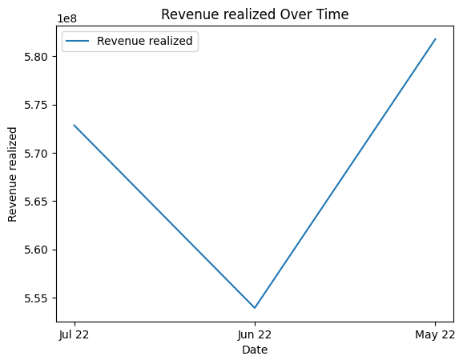

```python
import matplotlib.pyplot as plt

mybyrr = df_bookings_merged.groupby('mmm yy',as_index=False)['revenue_realized'].sum()
plt.plot(mybyrr['mmm yy'], mybyrr['revenue_realized'], label='Revenue realized')
plt.xlabel('Date')
plt.ylabel('Revenue realized')
plt.title('Revenue realized Over Time')
plt.legend()
plt.show()
```

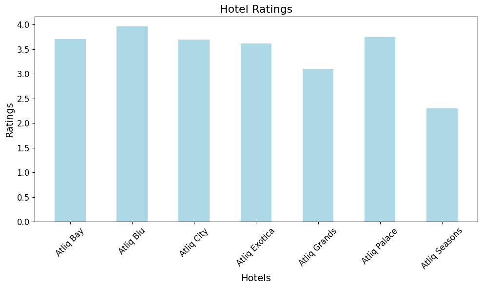

```python
plt.figure(figsize=(10, 6))  # Set the figure size

pnbyrg = df_bookings_merged.groupby("property_name", as_index = False)["ratings_given"].mean()
ax3 = plt.bar(pnbyrg["property_name"], pnbyrg["ratings_given"], color='lightblue',width=0.5)

# Add labels and title
plt.title('Hotel Ratings', fontsize=16)
plt.xlabel('Hotels', fontsize=14)
plt.ylabel('Ratings', fontsize=14)

# Rotate x-axis labels for better readability
plt.xticks(rotation=45, fontsize=12)
plt.yticks(fontsize=12)



# Show the chart
plt.tight_layout()  # Adjust layout to prevent overlap
plt.show()
```

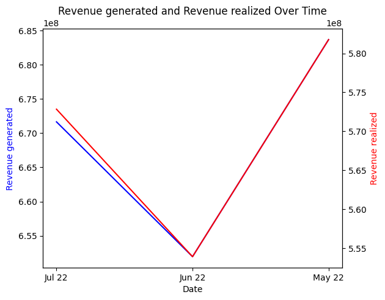

```python
fig, ax1 = plt.subplots()

mybyrg = df_bookings_merged.groupby('mmm yy',as_index=False)['revenue_generated'].sum()
ax1.plot(mybyrg['mmm yy'], mybyrg['revenue_generated'], 'b-', label='Revenue Generated')
ax1.set_xlabel('Date')
ax1.set_ylabel('Revenue generated', color='b')

mybyrr = df_bookings_merged.groupby('mmm yy',as_index=False)['revenue_realized'].sum()
ax2 = ax1.twinx()
ax2.plot(mybyrr['mmm yy'], mybyrr['revenue_realized'], 'r-', label='Revenue Realized')
ax2.set_ylabel('Revenue realized', color='r')

fig.tight_layout()
plt.title('Revenue generated and Revenue realized Over Time')
plt.show()
```